# examples_0317

Let the cardinality of the universal set be 65.

$$n(U)=65$$

Three subsets, $A$, $B$, and $C$ are visualized with a Venn diagram below. Each region's cardinality is shown.

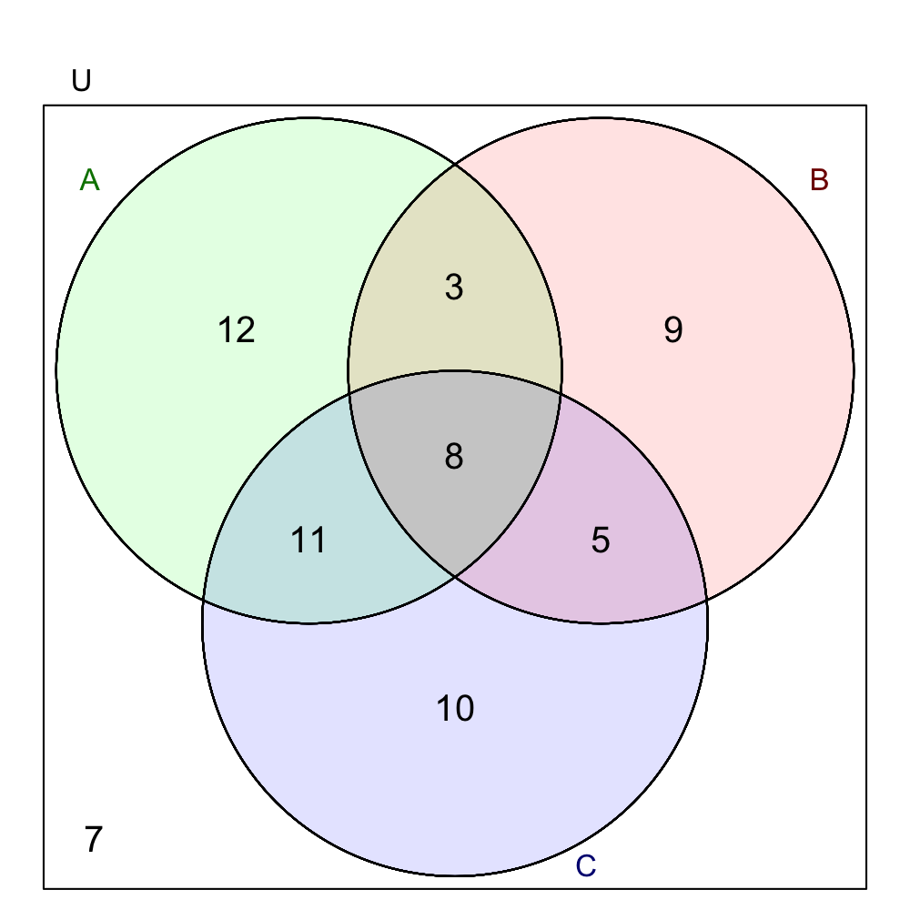

Find $n(A' \cup B')$.

The answer is 54.

Let the cardinality of the universal set be 80.

$$n(U)=80$$

Three subsets, $A$, $B$, and $C$ are visualized with a Venn diagram below. Each region's cardinality is shown.

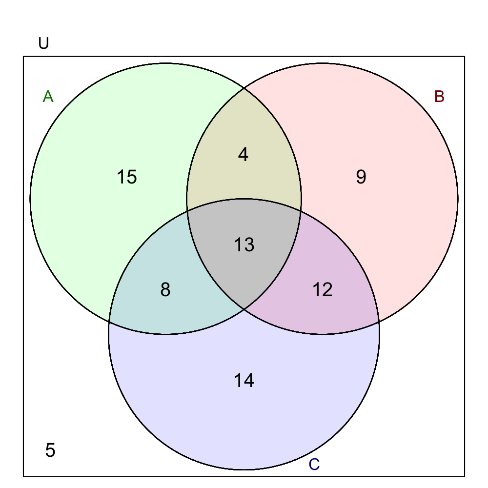

Find $n(A' \cap C)$.

The answer is 26.

Let the cardinality of the universal set be 94.

$$n(U)=94$$

Three subsets, $A$, $B$, and $C$ are visualized with a Venn diagram below. Each region's cardinality is shown.

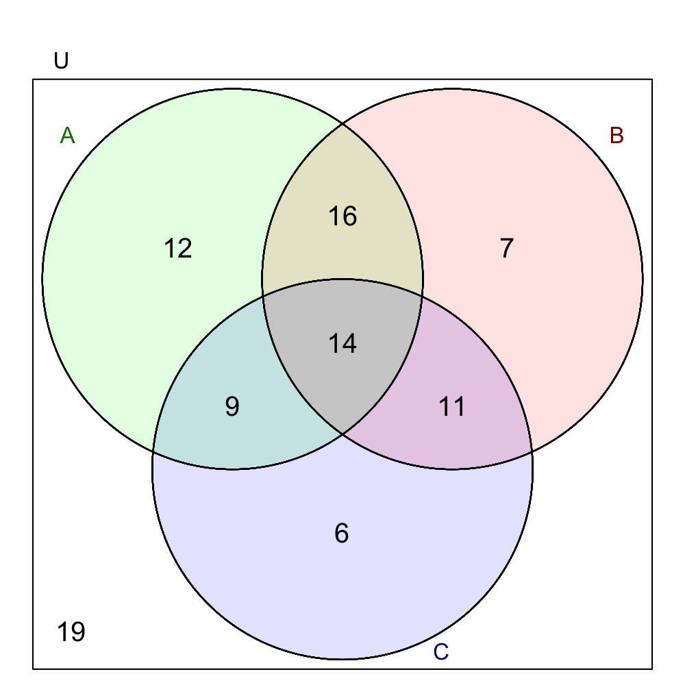

Find $n(A'\cap B' \cap C)$.

The answer is 6.

Let the cardinality of the universal set be 53.

$$n(U)=53$$

Three subsets, $A$, $B$, and $C$ are visualized with a Venn diagram below. Each region's cardinality is shown.

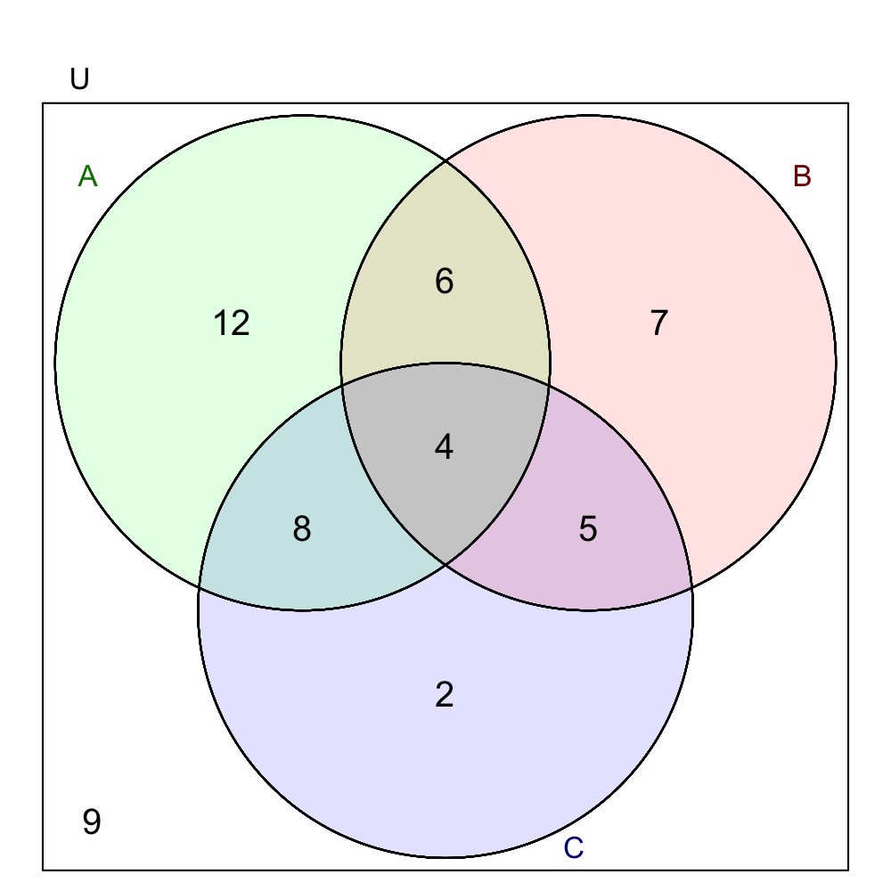

Find $n(A'\cap B \cap C')$.

The answer is 7.

Let the cardinality of the universal set be 74.

$$n(U)=74$$

Three subsets, $A$, $B$, and $C$ are visualized with a Venn diagram below. Each region's cardinality is shown.

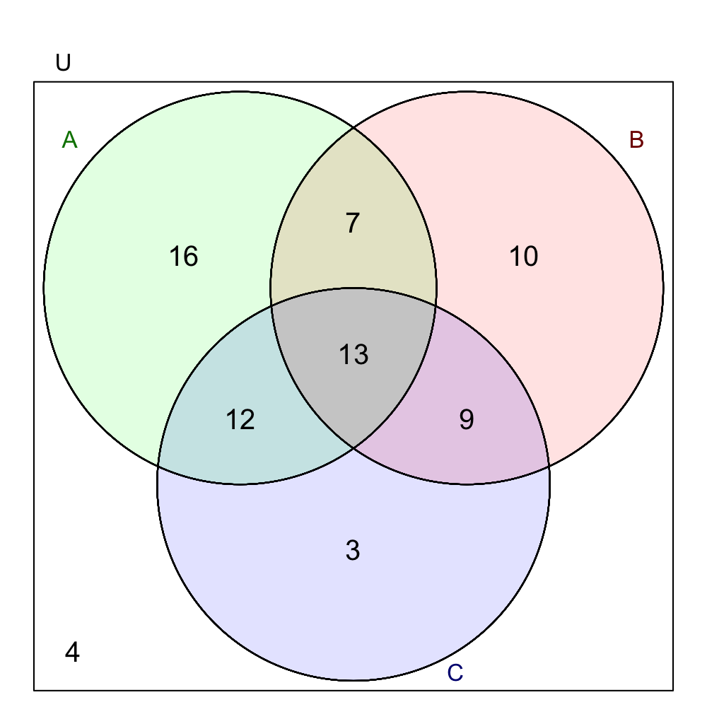

Find $n((B \cup C)')$.

The answer is 20.

Let the cardinality of the universal set be 98.

$$n(U)=98$$

Three subsets, $A$, $B$, and $C$ are visualized with a Venn diagram below. Each region's cardinality is shown.

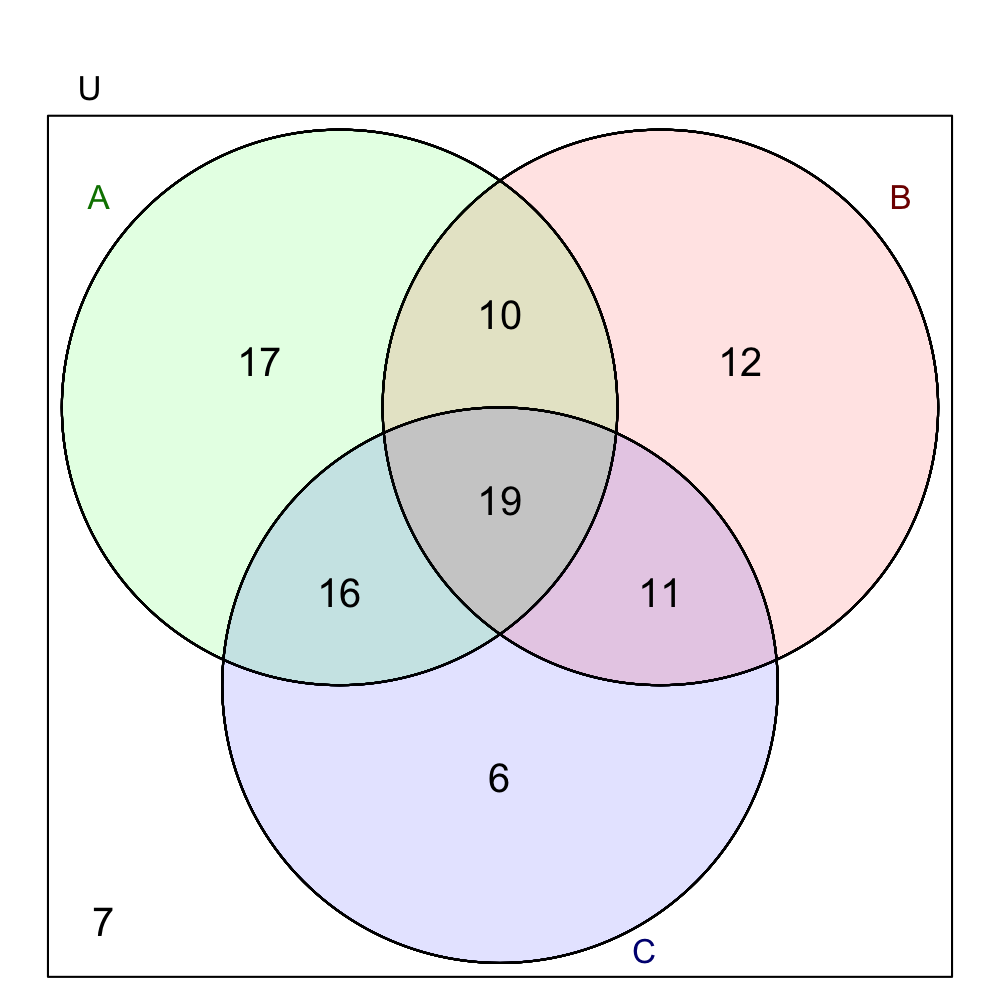

Find $n(A \cap B')$.

The answer is 33.

Let the cardinality of the universal set be 65.

$$n(U)=65$$

Three subsets, $A$, $B$, and $C$ are visualized with a Venn diagram below. Each region's cardinality is shown.

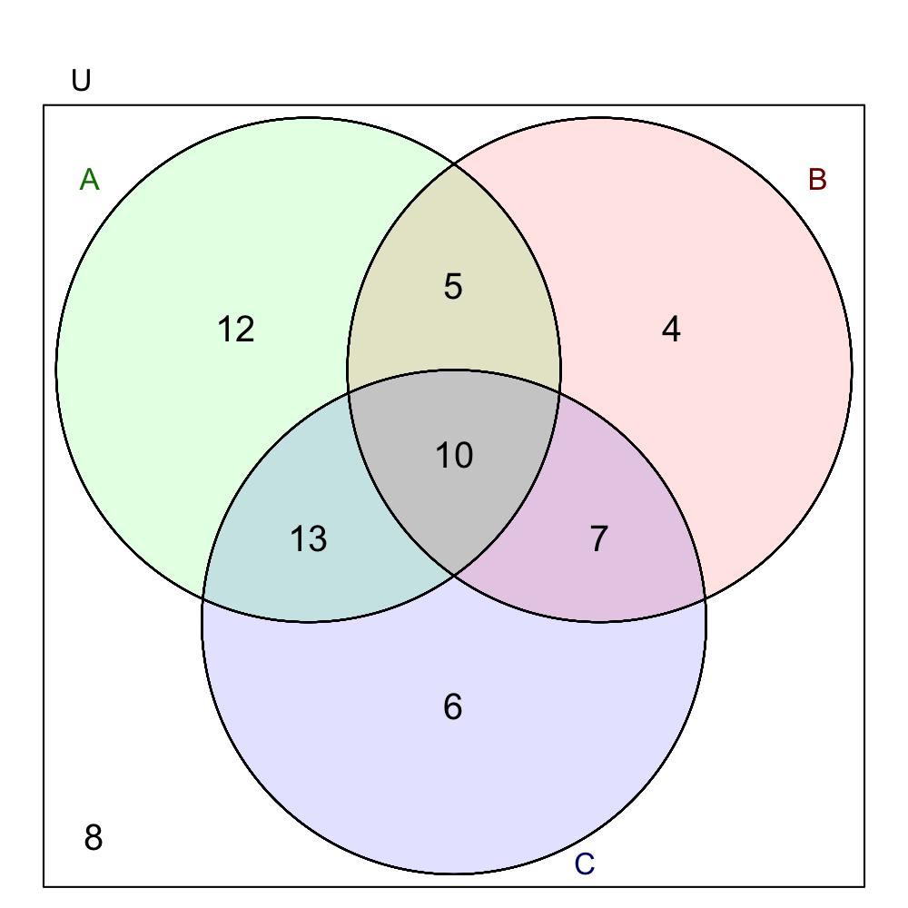

Find $n(B \cap C)$.

The answer is 17.

Let the cardinality of the universal set be 88.

$$n(U)=88$$

Three subsets, $A$, $B$, and $C$ are visualized with a Venn diagram below. Each region's cardinality is shown.

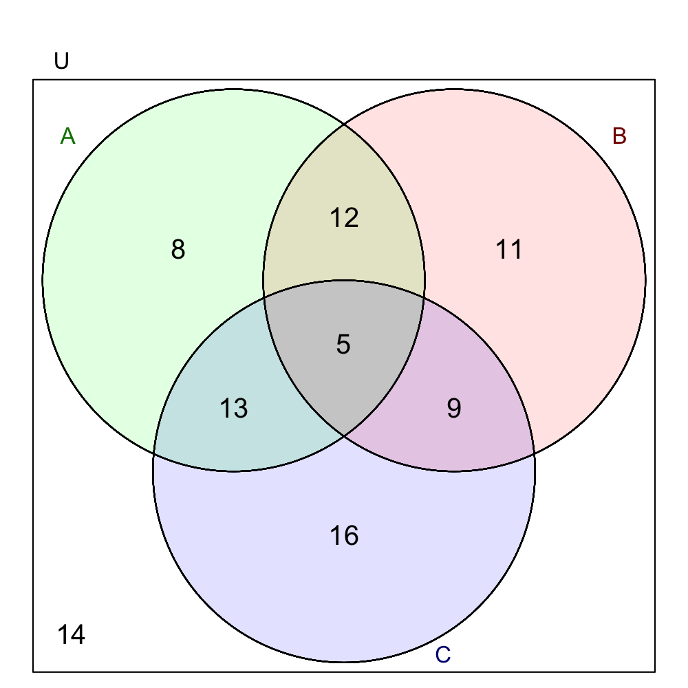

Find $n(C)$.

The answer is 43.

Let the cardinality of the universal set be 83.

$$n(U)=83$$

Three subsets, $A$, $B$, and $C$ are visualized with a Venn diagram below. Each region's cardinality is shown.

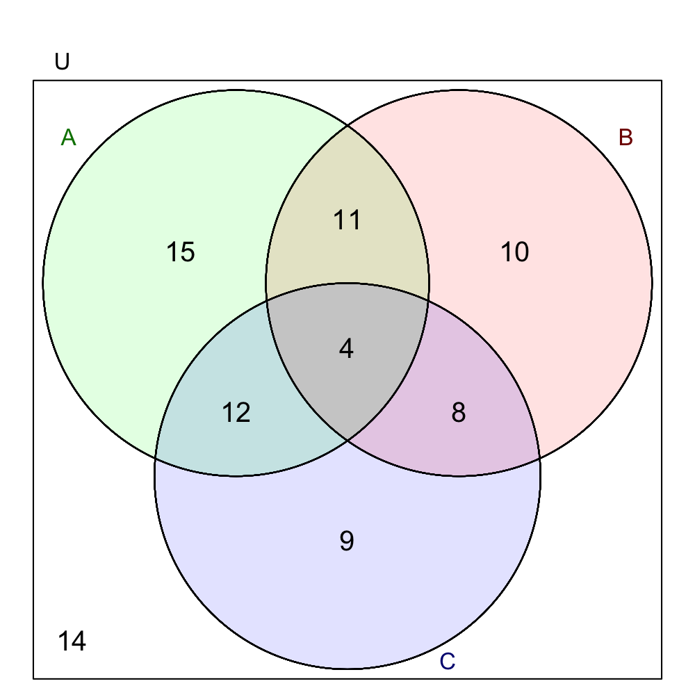

Find $n(A' \cap C')$.

The answer is 24.

Let the cardinality of the universal set be 93.

$$n(U)=93$$

Three subsets, $A$, $B$, and $C$ are visualized with a Venn diagram below. Each region's cardinality is shown.

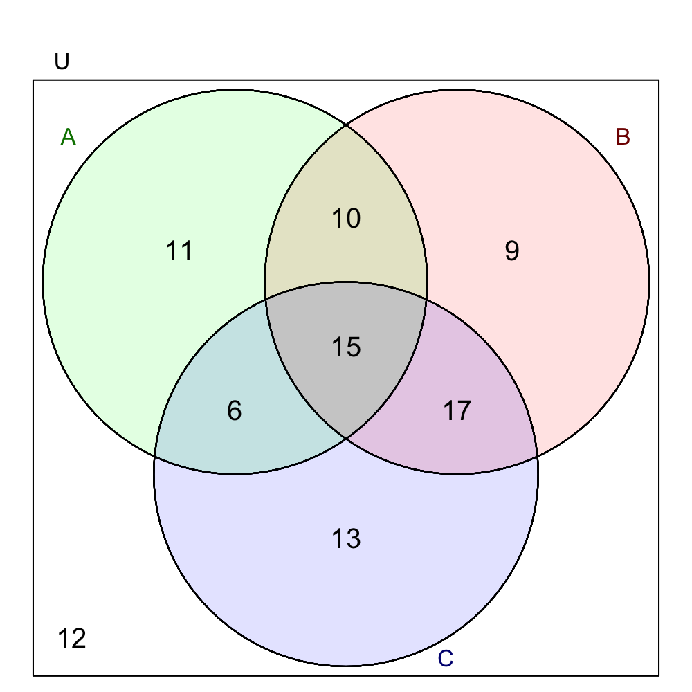

Find $n((B \cap C)')$.

The answer is 61.

Let the cardinality of the universal set be 91.

$$n(U)=91$$

Three subsets, $A$, $B$, and $C$ are visualized with a Venn diagram below. Each region's cardinality is shown.

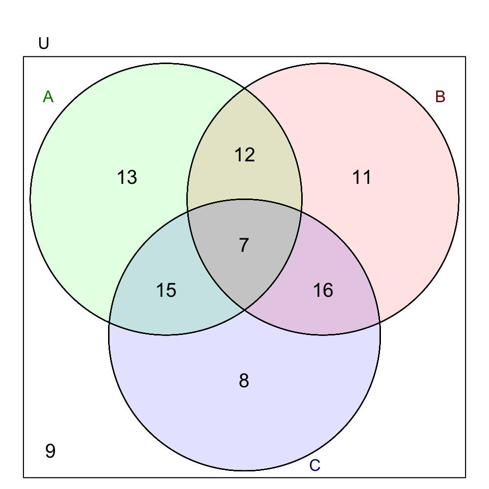

Find $n(A \cap B)$.

The answer is 19.

Let the cardinality of the universal set be 72.

$$n(U)=72$$

Three subsets, $A$, $B$, and $C$ are visualized with a Venn diagram below. Each region's cardinality is shown.

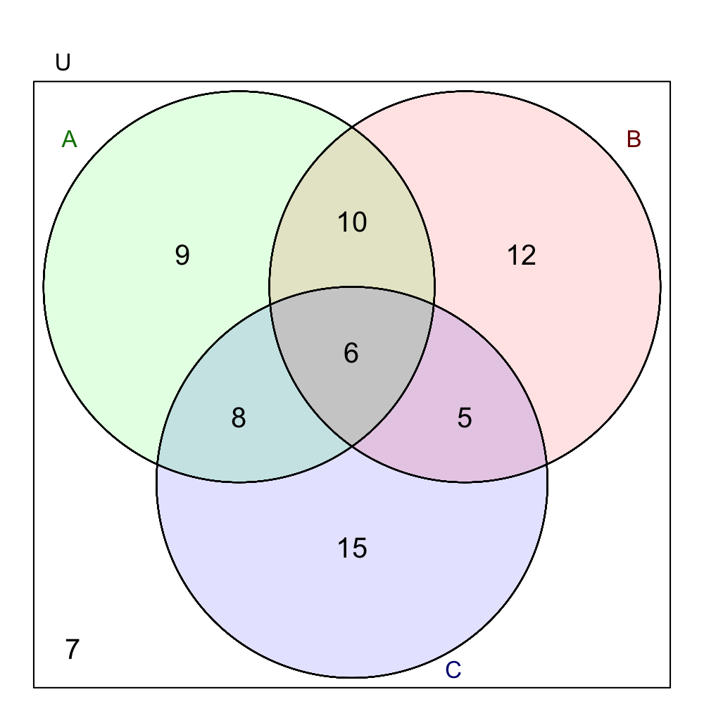

Find $n((B \cap C)')$.

The answer is 61.

Let the cardinality of the universal set be 77.

$$n(U)=77$$

Three subsets, $A$, $B$, and $C$ are visualized with a Venn diagram below. Each region's cardinality is shown.

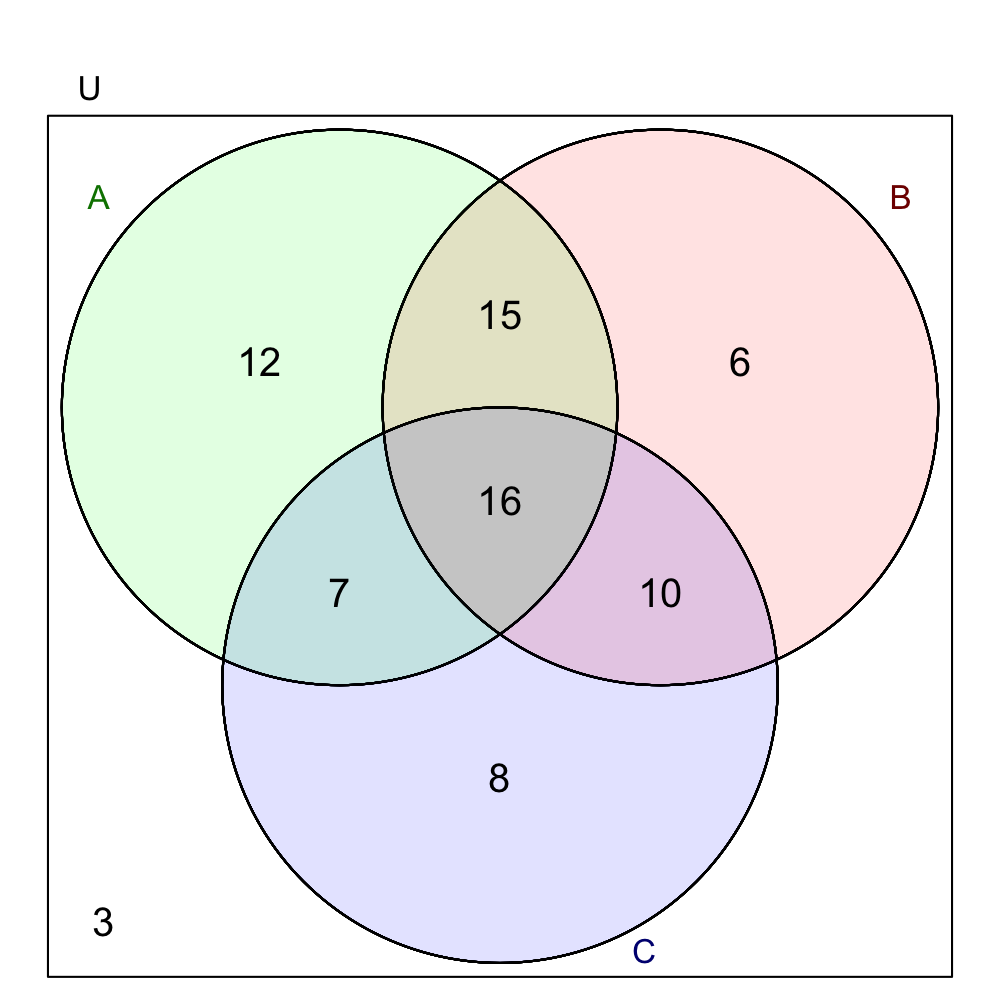

Find $n(A \cap B \cap C)$.

The answer is 16.

Let the cardinality of the universal set be 65.

$$n(U)=65$$

Three subsets, $A$, $B$, and $C$ are visualized with a Venn diagram below. Each region's cardinality is shown.

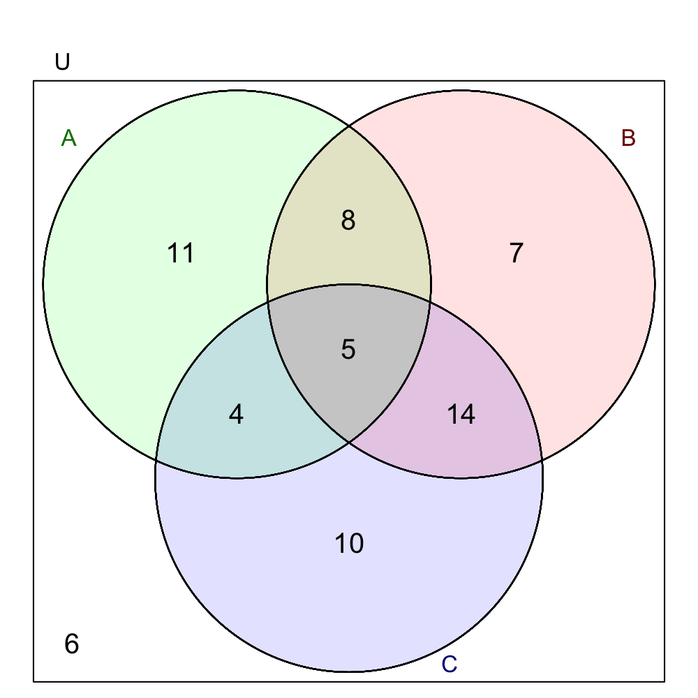

Find $n(A)$.

The answer is 28.

Let the cardinality of the universal set be 92.

$$n(U)=92$$

Three subsets, $A$, $B$, and $C$ are visualized with a Venn diagram below. Each region's cardinality is shown.

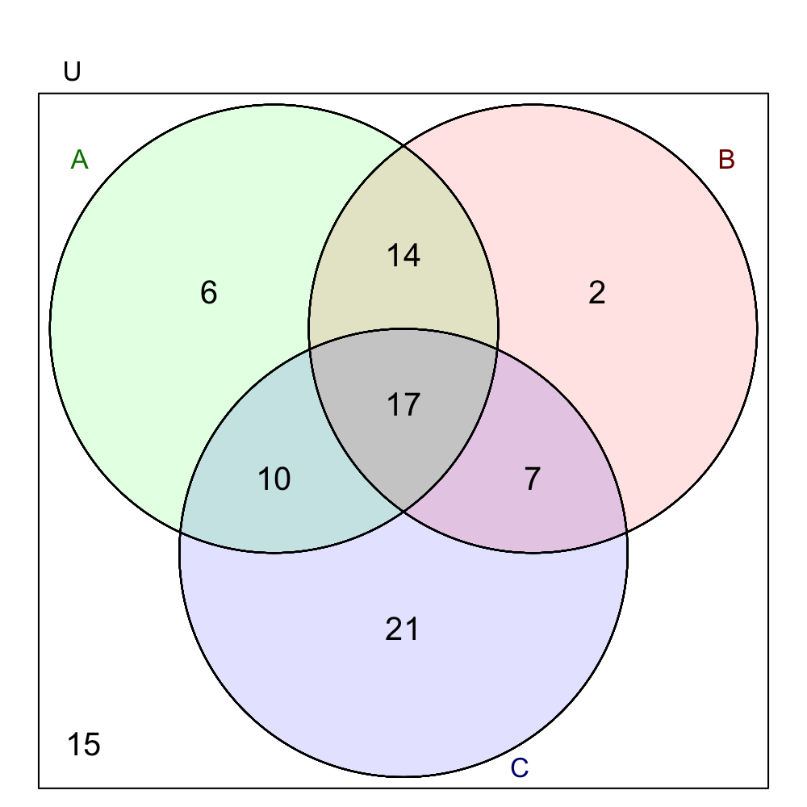

Find $n(A\cap B \cap C')$.

The answer is 14.

Let the cardinality of the universal set be 86.

$$n(U)=86$$

Three subsets, $A$, $B$, and $C$ are visualized with a Venn diagram below. Each region's cardinality is shown.

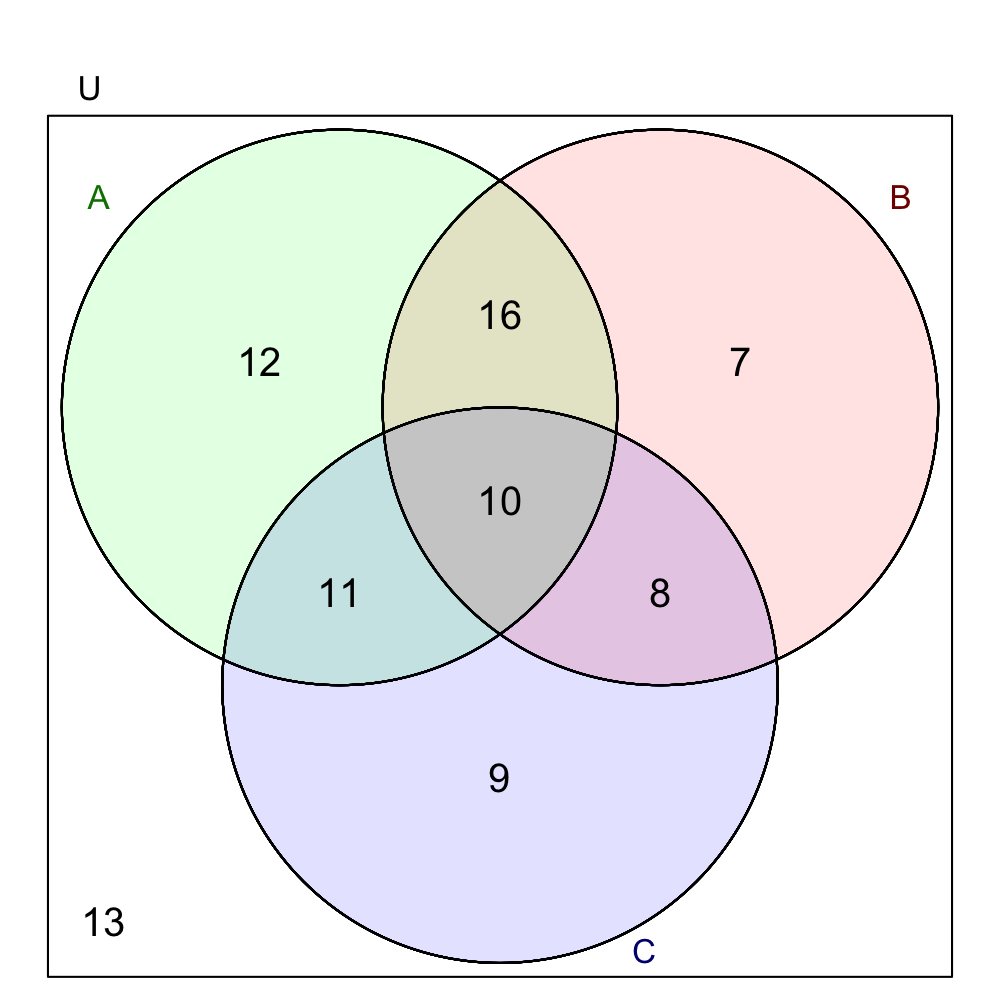

Find $n(A' \cap B \cap C)$.

The answer is 8.

Let the cardinality of the universal set be 77.

$$n(U)=77$$

Three subsets, $A$, $B$, and $C$ are visualized with a Venn diagram below. Each region's cardinality is shown.

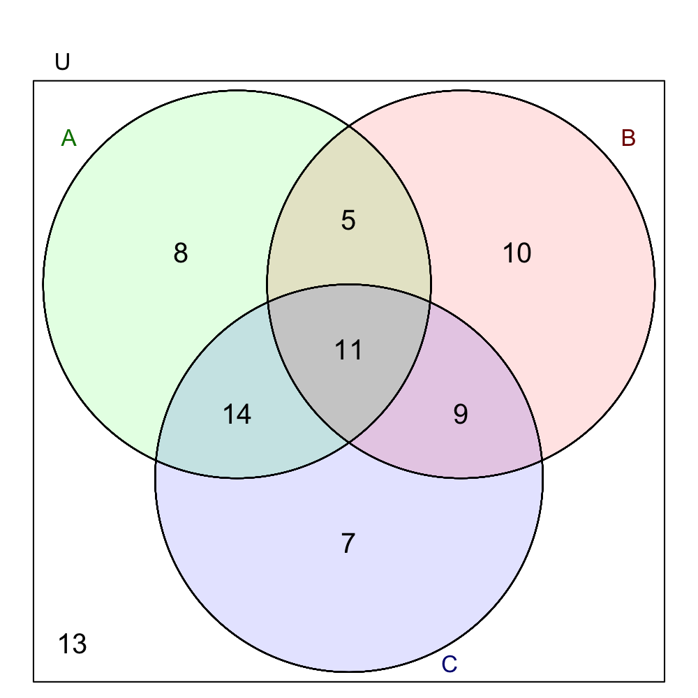

Find $n(C)$.

The answer is 41.

Let the cardinality of the universal set be 72.

$$n(U)=72$$

Three subsets, $A$, $B$, and $C$ are visualized with a Venn diagram below. Each region's cardinality is shown.

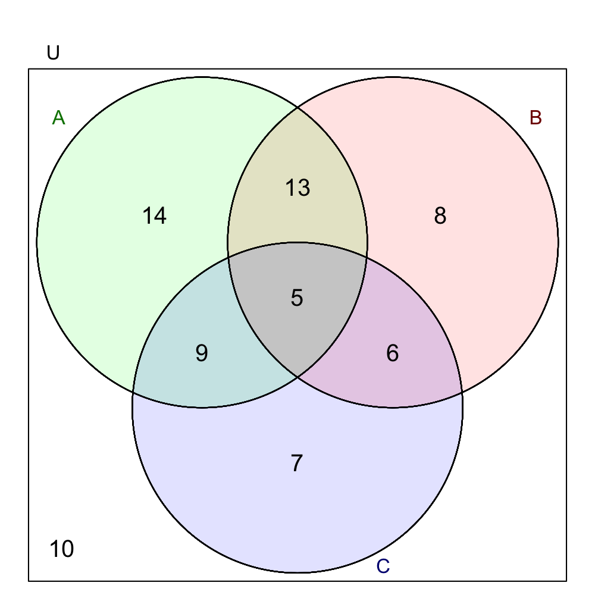

Find $n(A' \cap B)$.

The answer is 14.

Let the cardinality of the universal set be 99.

$$n(U)=99$$

Three subsets, $A$, $B$, and $C$ are visualized with a Venn diagram below. Each region's cardinality is shown.

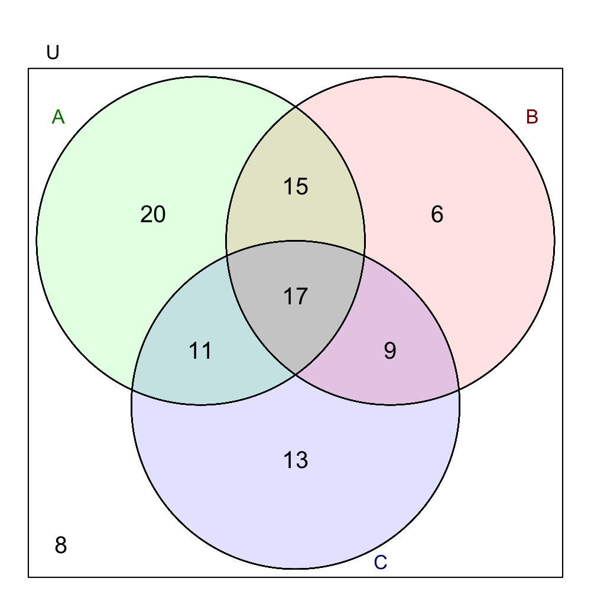

Find $n(A \cap C)$.

The answer is 28.

Let the cardinality of the universal set be 99.

$$n(U)=99$$

Three subsets, $A$, $B$, and $C$ are visualized with a Venn diagram below. Each region's cardinality is shown.

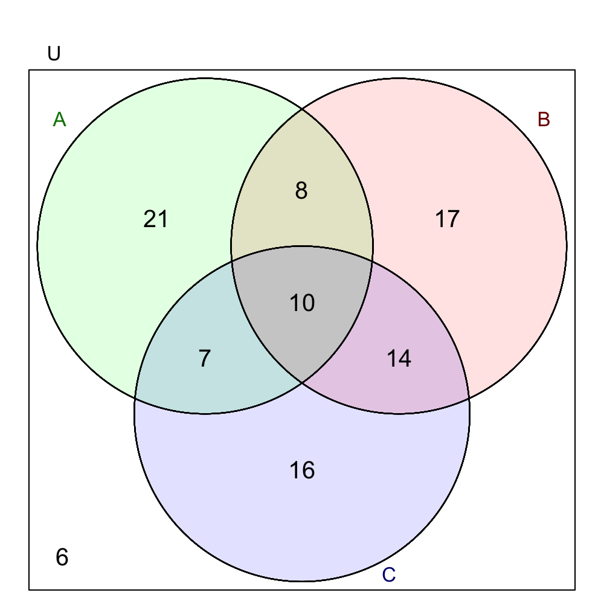

Find $n(B \cup C)$.

The answer is 72.